# NEE, LMA, and Foliar N

John W Smith

2/1/2022

## LMA

LMA stands for “Leaf Mass per Area”. In order to extract this, we will use information from the TRY database (Kattege et al, 2011; https://onlinelibrary.wiley.com/doi/full/10.1111/j.1365-2486.2011.02451.x).

The TRY database does not directly have LMA, but it does have Specific Leaf Area (SLA). In order to obtain the LMA, we will do some unit conversion from Table 5.

LMA has the units $\frac{gC}{m^2 LA}$, while SLA has the units $\frac{mm^2 LA}{mgC}$. Then, $\frac{1}{SLA}$ has the units $\frac{mgC}{mm^2 LA}$. We can do a simple unit conversion using the SLA for “Tree Needleleaved Evergreen” in Table 5, to obtain:

$\frac{1}{SLA} \frac{mgC}{mm^2 LA} \cdot \frac{1g}{1000mg} \frac{1000mm}{1m} \frac{1000mm}{1m} = 200 \frac{gC}{m^2 LA}$.

## Foliar N

To find the value of Foliar N we once again use the information from the TRY database. The value $N_a$ in Table 5 represents the leaf nitrogen content per area $\frac{g}{m^2}$. These are the exact units we are looking for in Foliar N as well - thus we can simply look at the value in Table 5 for “Tree Needleleaved Evergreen”, which gives us a value of $N_{fol} = 2.62$.

## NEE

The last of the information that we are trying to extract is NEE (Net Ecosystem Exchange), which comes to us as “NSAE” (Net Surface Atmosphere Exchange) from the NEON data.

We have some good starting points from the neon4cast resources, in particular the script here: https://github.com/eco4cast/neon4cast-terrestrial/blob/master/02_terrestrial_targets.R

```r
## load necessary libraries
library(neonUtilities)
library(neonstore)
library(tidyverse)
library(lubridate)
#library(contentid)
```

```r
## get NSAE data from neon
neon_download(product = 'DP4.00200.001', site = 'TALL')
```

```
##   comparing hashes against local file index...
```

```
##   updating release manifest...
```

```r
## read in NSAE data using neon_read
flux_data <- neon_read("nsae-basic", site = 'TALL')
```

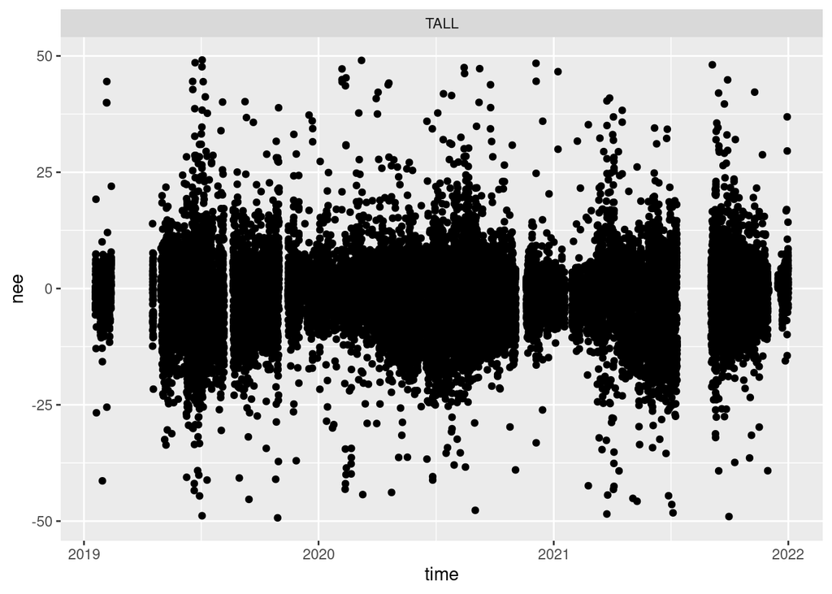

```r
## do some filtering of the flux data
co2_data <- flux_data %>%
  mutate(time = as_datetime(timeBgn)) %>%
  #filter(qfqm.fluxCo2.turb.qfFinl == 0 & data.fluxCo2.turb.flux > -50 & data.fluxCo2.turb.flux < 50 & data.fluxMome.turb.veloFric >= 0.1) %>%
  filter(data.fluxCo2.turb.flux > -50 &
           data.fluxCo2.turb.flux < 50 &
           data.fluxMome.turb.veloFric >= 0.1,
         year(time) >= 2019) %>%
  select(time,data.fluxCo2.turb.flux, siteID) %>%
  rename(nee = data.fluxCo2.turb.flux)
## plot filtered data
ggplot(co2_data, aes(x = time, y = nee)) +
  geom_point() +
  facet_wrap(~siteID)
```

```r
## aggregation
earliest <- min(as_datetime(c(co2_data$time)), na.rm = TRUE)
latest <- max(as_datetime(c(co2_data$time)), na.rm = TRUE)
full_time <- seq(min(c(co2_data$time), na.rm = TRUE),
                 max(c(co2_data$time), na.rm = TRUE),
                 by = "30 min")
full_time <- tibble(time = rep(full_time, 1),
                    siteID = c(rep("TALL", length(full_time))))

flux_target_30m <- left_join(full_time, co2_data, by = c("time", "siteID"))
threshold <- 40
valid_dates_nee <- flux_target_30m %>%
  mutate(date = as_date(time)) %>%
  filter(!is.na(nee)) %>% # & !is.na(le)) %>%
  group_by(date, siteID) %>%
  summarise(count = n()) %>%
  filter(count >= threshold)
flux_target_daily <- flux_target_30m %>%
  mutate(date = as_date(time)) %>%
  group_by(date, siteID) %>%
  summarize(nee = mean(nee, na.rm = TRUE)) %>%
  mutate(nee = ifelse(date %in% valid_dates_nee$date, nee, NA),
         nee = ifelse(is.nan(nee), NA, nee)) %>%
  rename(time = date) %>%
  mutate(nee = (nee * 12 / 1000000) * (60 * 60 * 24))
num_points <- flux_target_daily %>%
  na.omit() %>%
  nrow()
total_points <- flux_target_daily %>%
  nrow()
num_points/total_points
```

```
## [1] 0.4745134
```

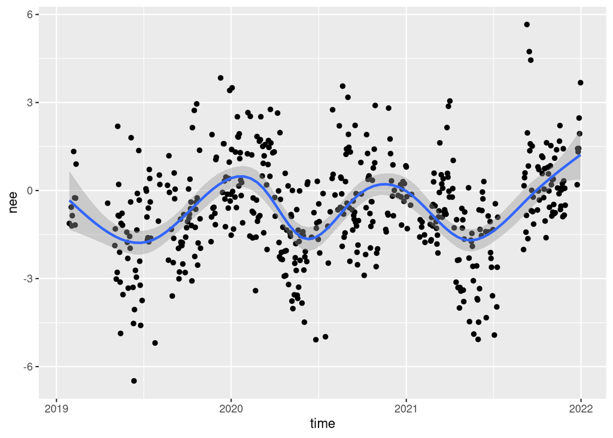

```r
## plot aggregated data
ggplot(flux_target_daily, aes(x = time, y = nee)) +
  geom_point() +
  geom_smooth()
```